# Co-occurrence Network Plotting colored by watertype

Xiu Jia

20 April, 2026

I used the script from the “Network Analysis Workshop” of National Centre for Soil Ecology Day on October 30, 2024, which is hosted by: Natalie Oram (UvA: n.j.oram@uva.nl) and Doina Bucur (UTwente: d.bucur@utwente.nl). It is suggested by Tianci on 25 Nov 2024 and implemented on 2 December 2024.

**This script to creating co-occurrence networks:** * The networks are built with with Spiec.Easi: https://github.com/zdk123/SpiecEasi, visualized with igraph: https://r.igraph.org/ and topology determined with various packages (igraph, braingraph). * We will use the feature table with raw number of reads in the table. These data have been aggregated to the Species level.

https://microbiome.github.io/OMA/docs/devel/pages/network_learning.html chrome-extension://efaidnbmnnnibpcajpcglclefindmkaj/https://epub.ub.uni-muenchen.de/74854/1/bbaa290.pdf

**Further reading:** - Kurtz et al., 2015. https://journals.plos.org/ploscompbiol/article?id=10.1371/journal.pcbi.1004226 - Chen et al., 2024. https://arxiv.org/pdf/2407.03897 - Chen and Bucur, 2024. https://link.springer.com/chapter/10.1007/978-3-031-57515-0_13 - Caruso et al., 2022. https://besjournals.onlinelibrary.wiley.com/doi/full/10.1111/2041-210X.13985 - Gueseva et al., 2022. https://www.sciencedirect.com/science/article/pii/S003807172200061X - Shan et al., 2023. https://www.nature.com/articles/s41559-023-02021-z - Naghshineh et al., 2025 Reorganization of bacterial community network structure in the eastern redback salamander (Plethodon cinereus) and its soil reservoir across a gradient of land use, FEMS Microbiology Ecology. https://doi.org/10.1093/femsec/fiaf057

# 0. Installing SpiecEasi on macOS (Apple Silicon)

**Prerequisites — run once in Terminal before opening R:**

**1. Install Xcode Command Line Tools**

Download **Command Line Tools for Xcode 16 beta 5** from https://developer.apple.com/download/all/ (free Apple ID required), install the `.dmg`, then run:

```bash
sudo xcode-select --switch /Library/Developer/CommandLineTools
# Verify it worked after installation completes
bashxcode-select -p
# Expected: /Library/Developer/CommandLineTools
clang --version
# Expected: Apple clang version 15.x.x ..
```

**2. Install gfortran**

Download **gfortran-14.2-ARM-Sequoia.dmg** from https://github.com/fxcoudert/gfortran-for-macOS/releases and install it.

Then add gfortran to your PATH:

```bash
echo 'export PATH="/usr/local/gfortran/bin:$PATH"' >> ~/.zshrc
source ~/.zshrc
# I got error in the begining as R can't find gfortran because it's not in the expected path.
# Verify gfortran is accessible
# Run this in your terminal and Verify it works now:
bashwhich gfortran
gfortran --version
```

**3. Configure R to find gfortran**

```bash
mkdir -p ~/.R
cat > ~/.R/Makevars << 'EOF'
FC = /usr/local/gfortran/bin/gfortran
F77 = /usr/local/gfortran/bin/gfortran
FLIBS = -L/usr/local/gfortran/lib/gcc/14 -L/usr/local/gfortran/lib -lgfortran -lquadmath -lm
EOF
```

**4. Install SpiecEasi — run in R:**

```r
# confirm everything is ready
pkgbuild::check_build_tools(debug = TRUE)
# Should return TRUE

remotes::install_github("zdk123/SpiecEasi")

# Verify
library(SpiecEasi)
```

# 1. Load libraries and work directory

```r
# clean the work enviornment
rm(list=ls())

library(tidyverse)
library(phyloseq)
library(microbiome)

library(SpiecEasi) # building network
library(igraph)

# library(ggplot2)
# library(dplyr)
# library(tidyr)
# library(purrr)
library(patchwork)
library(qgraph)        # smallworldness()
library(DescTools)     # AUC()
library(brainGraph)    # robustness()

library(intergraph)
library(GGally)
library(network)
library(ggrepel)
library(ggnewscale)   # two colour scales in one ggplot
library(Matrix)
library(patchwork)    # combine panels side-by-side
library(RColorBrewer)
library(stringr)
library(ggupset)
library(forcats)
library(circlize)


# change the base path where to save the outputs accordingly.
folder_path <- "network_Spiec_Easi_species/"
ALDEx2_path <- "ALDEx2_differential_analysis_source_coms_species/"
```

# 2. Network construction

## Step 1 – Load feature table (raw reads) and filter data

How you filter data is an important question to consider. One option is to remove low-abundance taxa or taxa that only occur in a small proportion of your experimental units. E.g. if taxa are only present in 5% of your 4 bacterial communities from seawater condition, it is likely that they don’t play an important role in your co-occurrence network (as their chance to ‘co-occur’ is quite small). How many nodes a network can handle will depend on the dataset (the variation in data). There’s no hard and fast number for this, but around 200-800 nodes generally works fine.

```r
## Load data
## The data format we need is a phyloseq object. Here, we combine the OTU table, (simplified) taxonomy table, and the sample metadata (all .csv files) into a phyloseq object. If you have the phloseq object, just start from there.

# read phyloseq object
ps_rawreads <- readRDS("phyloseq_object_species_rawreads.rds")

# only keep the samples from microcosm experiment
ps_microcosm <- subset_samples(ps_rawreads, category == "microcosm")

# remove taxa do not appear in any samples
ps_microcosm <- filter_taxa(ps_microcosm, function(x) sum(x) != 0, TRUE)
ps_microcosm
```

```
## phyloseq-class experiment-level object
## otu_table()   OTU Table:         [ 704 taxa and 240 samples ]
## sample_data() Sample Data:       [ 240 samples by 8 sample variables ]
## tax_table()   Taxonomy Table:    [ 704 taxa by 5 taxonomic ranks ]
```

```r
# saveRDS(ps_microcosm, file = "phyloseq_object_species_rawreads_microcosm.rds")

# Remove taxa not seen more than 5 times in at least 2% of the samples. This protects against an taxa with small mean & trivially large C.V.

# Filter taxa: more than 5 reads in at least 2% of samples
min_samples <- ceiling(0.02 * nsamples(ps_microcosm))
min_samples
```

```
## [1] 5
```

```r
# Remove taxa not seen more than 4 times of the samples. This protects against an taxa with small mean & trivially large C.V.
ps_microcosm_filtered <- filter_taxa(ps_microcosm, function(x) sum(x != 0) >= 4, prune = TRUE) # or replace the number by min_samples
ps_microcosm_filtered
```

```
## phyloseq-class experiment-level object
## otu_table()   OTU Table:         [ 401 taxa and 240 samples ]
## sample_data() Sample Data:       [ 240 samples by 8 sample variables ]
## tax_table()   Taxonomy Table:    [ 401 taxa by 5 taxonomic ranks ]
```

## Step 2 – Construt network for the full dataset

Below is the code to construct the network. This step is heavy on computational memory and very slow. So I have constructed networks in advance and loaded it later on. See https://github.com/zdk123/SpiecEasi for more details. This input for SPIEC-EASI is a counts table. The normalization and tranformation is done by the function. More information on [SPIEC-EASI](http://journals.plos.org/ploscompbiol/article?id=10.1371/journal.pcbi.1004226).

- Ingredients
- method: can be ‘mb’ (Neighborhood selection) or ‘glasso’ (inverse covariance selection)
- nlambda: tells the model how many different lambda values to try (how many ways to wire each node pair in the network). This essentially determines how complex your network is. A value between 20-120 is fine. Higher nlambda = more computational time and very high nlambda (> 150 or so) risks over fitting.
- lambda.min.ratio: determines/constrains the range of nlambda values (i.e. 1e-2 means that the smallest lambda value is 1% of the largest)
- pulsar.params: rep.num = number of times the network is re-sampled (bootstrapped), thresh: sets the stability threshold for edges in the network. 0.05 means that an edge must occur in 5% of the bootstrapped samples to be considered in the final model.
- sel.criterion: model sparseness is inferred using the Stability Approach to Regularization Selection (StARS), which involves random sub-sampling of the data set to find a network with low variability in the selected set of edges. character string specifying criterion/method for model selection. Accepts ‘stars’ [default], ‘bstars’ (Bounded StARS)
- The goal is to have a stable network >> target stability threshold (getStability) should be very close to 0.05. To improve the stability score, you can adjust:
- nlambda
- lambda.min.ratio
- sel.criterion

```r
## Parallel multicore ##
pargs <- list(rep.num=20, seed=210, ncores=4, thresh=0.05) # this is much faster by using more cores, but not work at this moment
pargs <- list(rep.num=20, seed=210, ncores=1, thresh=0.05)

## Construct the network
network_full_filtered <- spiec.easi(ps_microcosm_filtered, method='mb', nlambda=120, lambda.min.ratio=1e-2,
                                     pulsar.params=pargs, sel.criterion='bstars')


getStability(network_full_filtered) # Should be close to 0.05, now 0.04794127

## Save network
# saveRDS(network_full_filtered, paste0(folder_path, "network_full_filtered.rds"))
```

# 3. Network validation (quality & robustness)

SpiecEasi networks require three levels of validation before ecological interpretation:

| Level | What it tests | Key metric |
| --- | --- | --- |
| 1. Internal stability | Did the StARS/bSTARS selection converge? | `getStability()` ≈ 0.05 |
| 2. Non-randomness | Is the observed network different from random? | Compare topology to null ensemble |
| 3. Small-world topology | Is the network biologically plausible? | σ = (C/C_rand) / (L/L_rand) > 1 |

## Step 1 – Re-load the network & topology metrics

```r
# ── Load SpiecEasi network ────────────────────────────────────────────────────
network_full_filtered <- readRDS(paste0(folder_path, "network_full_filtered.rds"))

# ── 1. StARS stability score ──────────────────────────────────────────────────
stability <- getStability(network_full_filtered)
cat(glue::glue("
── 1. StARS stability ────────────────────────────────
  Stability score : {round(stability, 5)}
  Target          : ≤ 0.05
  Status          : {ifelse(stability <= 0.05, '✓ PASS — network is stable', '✗ FAIL — consider adjusting nlambda')}
──────────────────────────────────────────────────────
\n"))
```

```
## ── 1. StARS stability ────────────────────────────────
##   Stability score : 0.04794
##   Target          : ≤ 0.05
##   Status          : ✓ PASS — network is stable
## ──────────────────────────────────────────────────────
```

```r
# Convert adjacency network to igraph format
ig_network_full_filtered <- adj2igraph(getRefit(network_full_filtered), diag=TRUE,
                                       vertex.attr=list(name=taxa_names(ps_microcosm_filtered)))
ig_network_full_filtered
```

```
## IGRAPH 6ebce8e UNW- 401 2040 --
## + attr: name (v/c), weight (e/n)
## + edges from 6ebce8e (vertex names):
##  [1] Malikia spinosa--Rheinheimera riviphila
##  [2] Malikia spinosa--Shewanella baltica
##  [3] Malikia spinosa--Acinetobacter haemolyticus
##  [4] Malikia spinosa--Acinetobacter pragensis
##  [5] Malikia spinosa--Hydrogenophaga crassostreae
##  [6] Malikia spinosa--Malikia granosa
##  [7] Malikia spinosa--Rhodoferax sp. Gr-4
##  [8] Malikia spinosa--Hydrogenophaga soli
## + ... omitted several edges
```

```r
## Extract edge list and attributes
edgelist_network_full_filtered <- as_edgelist(ig_network_full_filtered, names = FALSE)
edgelist_network_full_filtered <- as.data.frame(edgelist_network_full_filtered)
edgelist_network_full_filtered[1:5,]
```

```
##   V1  V2
## 1  1  19
## 2  1  60
## 3  1 129
## 4  1 131
## 5  1 182
```

```r
## Extract adjacency matrix
adj_network_full_filtered <- as_adjacency_matrix(ig_network_full_filtered, sparse=FALSE)
adj_network_full_filtered <- as.data.frame(adj_network_full_filtered)
adj_network_full_filtered[1:3, 1:2]
```

```
##                               Malikia spinosa Pseudoalteromonas arctica
## Malikia spinosa                             0                         0
## Pseudoalteromonas arctica                   0                         0
## Pseudoalteromonas sp. 16-SW-7               0                         1
```

```r
# write.csv(adj_network_full_filtered, paste0(folder_path, "full_network_adj_matrix.csv"))


# ── 2. Basic network properties ───────────────────────────────────────────────
n_nodes    <- vcount(ig_network_full_filtered)
n_edges    <- ecount(ig_network_full_filtered)
density    <- edge_density(ig_network_full_filtered)
components <- components(ig_network_full_filtered)
# summary(weight)
# hist(weight, breaks = 50,
#      main = "Distribution of partial correlation coefficients (β)",
#      xlab = "β coefficient")

betaMat  <- as.matrix(symBeta(getOptBeta(network_full_filtered)))
n_pos    <- length(betaMat[betaMat > 0]) / 2
n_neg    <- length(betaMat[betaMat < 0]) / 2

cat(glue::glue("
── 2. Basic network properties ──────────────────────
  Nodes                  : {n_nodes}
  Edges                  : {n_edges}
  Density                : {round(density, 4)}
  Connected components   : {components$no}
  Positive edges         : {n_pos}  ({round(100*n_pos/n_edges, 1)}%)
  Negative edges         : {n_neg}  ({round(100*n_neg/n_edges, 1)}%)
──────────────────────────────────────────────────────
\n"))
```

```
## ── 2. Basic network properties ──────────────────────
##   Nodes                  : 401
##   Edges                  : 2040
##   Density                : 0.0254
##   Connected components   : 1
##   Positive edges         : 1940  (95.1%)
##   Negative edges         : 100  (4.9%)
## ──────────────────────────────────────────────────────
```

```r
# ── 3. Observed topology metrics ─────────────────────────────────────────────
obs_transitivity  <- transitivity(ig_network_full_filtered, type = "average")
obs_mean_path     <- mean_distance(ig_network_full_filtered, directed = FALSE)
obs_modularity    <- modularity(cluster_louvain(ig_network_full_filtered))
obs_mean_between  <- mean(betweenness(ig_network_full_filtered))
obs_mean_degree   <- mean(degree(ig_network_full_filtered))

cat(glue::glue("
── 3. Observed topology ─────────────────────────────
  Clustering coefficient : {round(obs_transitivity, 4)}
  Mean path length       : {round(obs_mean_path, 4)}
  Modularity (Louvain)   : {round(obs_modularity, 4)}
  Mean betweenness       : {round(obs_mean_between, 2)}
  Mean degree            : {round(obs_mean_degree, 2)}
──────────────────────────────────────────────────────
\n"))
```

[output not shown]

```r
# ── 4. Small-world index (σ) ──────────────────────────────────────────────────
# σ > 1 means the network is more clustered than random but not much longer path
# Uses 100 Erdos-Renyi random graphs with same N and edge density

set.seed(42)
n_rand <- 100
rand_trans  <- numeric(n_rand)
rand_path   <- numeric(n_rand)

for (i in seq_len(n_rand)) {
  g_rand         <- erdos.renyi.game(n_nodes, n_edges, type = "gnm")
  rand_trans[i]  <- transitivity(g_rand, type = "average")
  rand_path[i]   <- mean_distance(g_rand, directed = FALSE)
}

C_rand <- mean(rand_trans, na.rm = TRUE)
L_rand <- mean(rand_path,  na.rm = TRUE)

gamma <- obs_transitivity / C_rand     # clustering ratio
lambda <- obs_mean_path   / L_rand     # path length ratio
sigma  <- gamma / lambda               # small-world index

cat(glue::glue("
── 4. Small-world index ─────────────────────────────
  C_obs / C_rand  (γ)    : {round(gamma, 3)}   (> 1 = more clustered than random)
  L_obs / L_rand  (λ)    : {round(lambda, 3)}   (≈ 1 = similar path length to random)
  Small-world σ = γ/λ    : {round(sigma, 3)}
  Interpretation         : {ifelse(sigma > 1, '✓ Small-world network confirmed (σ > 1)', '✗ Not small-world (σ ≤ 1)')}
──────────────────────────────────────────────────────
\n"))
```

```
## ── 4. Small-world index ─────────────────────────────
##   C_obs / C_rand  (γ)    : 6.755   (> 1 = more clustered than random)
##   L_obs / L_rand  (λ)    : 1.15   (≈ 1 = similar path length to random)
##   Small-world σ = γ/λ    : 5.876
##   Interpretation         : ✓ Small-world network confirmed (σ > 1)
## ──────────────────────────────────────────────────────
```

## Step 2 – Permutation to generate null ensemble

Permutation has been run before, so we just need to load it in the next step.

````r
# ── Generate null model ensemble in R ────────────────────────────────────────
# Method: degree-preserving edge rewiring (Maslov-Sneppen algorithm)
# This preserves the degree sequence of each node while randomising
# which nodes are connected — the standard null model for ecological networks
# igraph contains a function to rewire networks. We will rewire 100x edges while preserving the original degree distribution. 10x permutations should give an idea of the variation in centralities. For each of the permutations, we can generate a similar dataframe as the centralities dataframe generated for the original graph.


n_nulls  <- 999    # number of null models — 999 is standard in the literature
niter    <- 100    # rewiring iterations per edge (higher = more randomised)
                   # recommended: 100× number of edges

set.seed(42)

cat(glue::glue("
── Generating {n_nulls} null models ─────────────────────
  Method : degree-preserving edge rewiring
  Network: {vcount(ig_network_full_filtered)} nodes, {ecount(ig_network_full_filtered)} edges
  niter  : {niter} rewiring attempts per edge
  This will take several minutes...
──────────────────────────────────────────────────────
\n"))

# ── Helper: generate one null graph ──────────────────────────────────────────
make_null_graph <- function(g, niter) {
  # rewire() shuffles edges while preserving degree sequence
  g_null <- rewire(g, with = keeping_degseq(niter = niter * ecount(g))) # 204,000 attempts per edge — 10× edges is commonly used in ecology papers
  # simplify removes any self-loops or multi-edges introduced by rewiring
  g_null <- igraph::simplify(g_null)
  g_null
}

# ── Generate the ensemble with progress reporting ─────────────────────────────
# Use a simple loop so progress is visible
null_graph_list <- vector("list", n_nulls)

for (i in seq_len(n_nulls)) {
  null_graph_list[[i]] <- make_null_graph(ig_network_full_filtered, niter)
  if (i %% 100 == 0) cat("  Generated", i, "/", n_nulls, "null models\n")
}

cat("Done! Saving null ensemble...\n")

# ── Save for later use ────────────────────────────────────────────────────────
saveRDS(null_graph_list,  paste0(folder_path, "null_graph_list.rds"))

cat("Saved to:", paste0(folder_path, "null_graph_list.rds"), "\n")

# ```

# Re-load the permutations for statistical test:
# ```{r null-ensemble-metrics, eval = FALSE, message=FALSE, warning=FALSE}

# ── 5. Compare observed vs null ensemble topology ─────────────────────────────
# Load null ensemble from previous steps
null_graph_list <- readRDS(paste0(folder_path, "null_graph_list.rds"))

cat("Loaded", length(null_graph_list), "null models\n")
cat("First null graph:", vcount(null_graph_list[[1]]),
    "nodes,", ecount(null_graph_list[[1]]), "edges\n")

# ── Verify degree sequence is preserved ──────────────────────────────────────
# The mean degree of null models should match the observed network
obs_deg   <- mean(degree(ig_network_full_filtered))
null_deg  <- mean(sapply(null_graph_list[1:10],
                          function(g) mean(degree(g))))
cat(glue::glue("
── Degree preservation check ────────────────────────
  Observed mean degree    : {round(obs_deg, 3)}
  Null mean degree (n=10) : {round(null_deg, 3)}
  Match                   : {ifelse(abs(obs_deg - null_deg) < 0.01, '✓ OK', '✗ Check rewiring')}
──────────────────────────────────────────────────────
\n"))

# ── Compute topology metrics for each null graph ──────────────────────────────
compute_null_metrics <- function(g) {
  list(
    transitivity  = transitivity(g, type = "average"),
    mean_path     = tryCatch(
                      mean_distance(g, directed = FALSE),
                      error = function(e) NA_real_),
    modularity    = modularity(cluster_louvain(g)),
    mean_between  = mean(betweenness(g, normalized = TRUE))
  )
}


cat("Computing topology for", length(null_graph_list), "null models...\n")
null_metrics   <- purrr::map(null_graph_list, compute_null_metrics)
null_df        <- bind_rows(null_metrics) %>% mutate(type = "Null")

# ── Compute AUC robustness for null ensemble ──────────────────────────────────
# Uses degree-targeted attack robustness from brainGraph
# library(brainGraph)

robust_null <- purrr::map(null_graph_list, function(g) {
  tryCatch(
    robustness(g, type = "vertex", measure = "degree"),
    error = function(e) NULL
  )
})

# remove any failed runs
robust_null  <- compact(robust_null)

auc_null <- map_dbl(robust_null, function(r) {
  AUC(r$removed.pct, r$comp.pct)
})

null_df$AUC <- c(auc_null, rep(NA, nrow(null_df) - length(auc_null)))

# ── Save null metrics for use in validation plots ─────────────────────────────
write.csv(null_df, paste0(folder_path, "null_ensemble_topology.csv"),
          row.names = FALSE)

cat("Null ensemble metrics saved.\n")
````

## Step 3 – Plot the results

```r
null_df <- read.csv(paste0(folder_path, "null_ensemble_topology.csv"))
summary(null_df)
```

```
##   transitivity       mean_path       modularity      mean_between
##  Min.   :0.01956   Min.   :2.820   Min.   :0.2657   Min.   :0.004561
##  1st Qu.:0.02443   1st Qu.:2.826   1st Qu.:0.2788   1st Qu.:0.004576
##  Median :0.02585   Median :2.828   Median :0.2824   Median :0.004581
##  Mean   :0.02589   Mean   :2.828   Mean   :0.2824   Mean   :0.004581
##  3rd Qu.:0.02724   3rd Qu.:2.830   3rd Qu.:0.2859   3rd Qu.:0.004586
##  Max.   :0.03279   Max.   :2.838   Max.   :0.2994   Max.   :0.004607
##      type                AUC
##  Length:999         Min.   :0.4205
##  Class :character   1st Qu.:0.4326
##  Mode  :character   Median :0.4365
##                     Mean   :0.4364
##                     3rd Qu.:0.4403
##                     Max.   :0.4565
```

```r
obs_df <- data.frame(
  transitivity = obs_transitivity,
  mean_path    = obs_mean_path,
  modularity   = obs_modularity,
  mean_between = obs_mean_between,
  type         = "Observed"
)

combined_df <- bind_rows(null_df, obs_df)

# ── 6. Z-scores: how many SDs is the observed from the null mean? ─────────────
z_scores <- null_df %>%
  summarise(across(where(is.numeric), list(mean = mean, sd = sd), na.rm = TRUE)) %>%
  pivot_longer(everything(),
               names_to  = c("metric", ".value"),
               names_sep = "_(?=[^_]+$)") %>%
  left_join(
    obs_df %>% pivot_longer(-type, names_to = "metric", values_to = "obs"),
    by = "metric"
  ) %>%
  mutate(
    z        = (obs - mean) / sd,
    p_approx = 2 * pnorm(-abs(z)),   # two-tailed approximate p-value
    sig      = case_when(
      p_approx < 0.001 ~ "***",
      p_approx < 0.01  ~ "**",
      p_approx < 0.05  ~ "*",
      TRUE              ~ "ns"
    )
  )

cat("\n── 5. Z-scores vs null ensemble ─────────────────────\n")
```

```
##
## ── 5. Z-scores vs null ensemble ─────────────────────
```

```r
print(z_scores %>% dplyr::select(metric, obs, mean, sd, z, p_approx, sig),
      digits = 3)
```

```
## # A tibble: 5 × 7
##   metric           obs    mean         sd          z p_approx sig
##   <chr>          <dbl>   <dbl>      <dbl>      <dbl>    <dbl> <chr>
## 1 transitivity   0.173 0.0259  0.00213          69.0        0 ***
## 2 mean_path      3.25  2.83    0.00305         138.         0 ***
## 3 modularity     0.529 0.282   0.00524          47.2        0 ***
## 4 mean_between 450.    0.00458 0.00000763 58911390.         0 ***
## 5 AUC           NA     0.436   0.00542          NA         NA ns
```

```r
cat("──────────────────────────────────────────────────────\n")
```

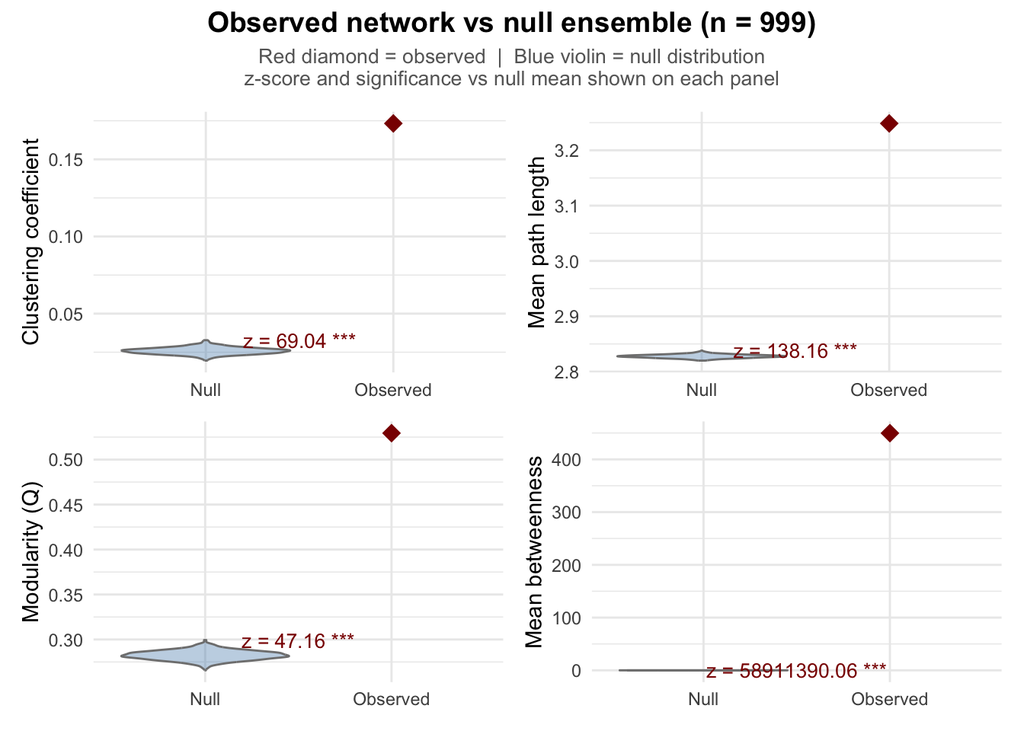

```r
# ── 7. Violin plots: observed vs null ─────────────────────────────────────────
plot_metric <- function(metric_name, y_label) {
  ggplot() +
    geom_violin(
      data  = null_df,
      aes(x = "Null", y = .data[[metric_name]]),
      fill  = "steelblue", alpha = 0.35, colour = "grey50"
    ) +
    geom_point(
      data   = obs_df,
      aes(x  = "Observed", y = .data[[metric_name]]),
      colour = "darkred", size = 4, shape = 18
    ) +
    annotate("text",
             x     = 1.5,
             y     = max(null_df[[metric_name]], na.rm = TRUE),
             label = paste0("z = ",
                            round(z_scores$z[z_scores$metric == metric_name], 2),
                            " ", z_scores$sig[z_scores$metric == metric_name]),
             size  = 3.5, colour = "darkred") +
    labs(title = NULL, x = NULL, y = y_label) +
    theme_minimal(base_size = 11) +
    theme(plot.title = element_text(face = "bold", hjust = 0.5, size = 11))
}

pv1 <- plot_metric("transitivity",  "Clustering coefficient")
pv2 <- plot_metric("mean_path",     "Mean path length")
pv3 <- plot_metric("modularity",    "Modularity (Q)")
pv4 <- plot_metric("mean_between",  "Mean betweenness")

(pv1 | pv2) / (pv3 | pv4) +
  plot_annotation(
    title    = "Observed network vs null ensemble (n = 999)",
    subtitle = paste0(
      "Red diamond = observed  |  Blue violin = null distribution\n",
      "z-score and significance vs null mean shown on each panel"
    ),
    theme = theme(
      plot.title    = element_text(face = "bold", hjust = 0.5, size = 14),
      plot.subtitle = element_text(hjust = 0.5, colour = "grey40", size = 10)
    )
  )
```

```r
ggsave(paste0(folder_path, "network_validation_vs_null.pdf"),  width = 6, height = 5)
ggsave(paste0(folder_path, "network_validation_vs_null.png"),  width = 6, height = 5,
       dpi = 300, bg = "white")
```